```python
import pysm
import pysm.units as u
import healpy as hp
import numpy as np
import matplotlib.pyplot as plt
import pylab as pl
from pylab import cm
cmap = cm.get_cmap('RdYlBu')
cmap.set_under('w')
%matplotlib inline
```

```python
from IPython.display import HTML

HTML('''<script>
code_show=true;
function code_toggle() {
 if (code_show){
 $('div.input').hide();
 } else {
 $('div.input').show();
 }
 code_show = !code_show
}
$( document ).ready(code_toggle);
</script>
<form action="javascript:code_toggle()"><input type="submit" value="Click here to toggle on/off the raw code."></form>''')
```

# Photon Load from Galactic emission

In this posting, we aim at characterizing the photon load due to the Galactic emission in the Litebird frequency bands. We mostly focus in the regions where the emission is brighter, i.e. in the Galactic Center.

### Simulation setup

We used [PySM](https://github.com/healpy/pysm) package to simulate the emission from : *Thermal Dust, Synchrotron, AME, Free-Free, CO*.  
The PySM models specs chosen for these components are `d1s1f1a1`.

We used the nominal values for the frequency bands reported in the [IMOv0](https://wiki.kek.jp/pages/viewpage.action?pageId=108104267). We further convolved the simulated maps by the nominal beam FWHM reported in the IMO.

The photon load is obtained then as the maximum pixel value (in $ K_{RJ}$ ) from a circle centred at $(\ell, b )= 0,0 $deg and radius $20 $ arcmin. We plot the Temperature vs the frequency band centroid.

```python
nside=512

print("Pixel size chosen for map sims : {:.2f} arcmin".format( hp.nside2resol(nside , arcmin=True)))
```

```
Pixel size chosen for map sims : 6.87 arcmin
```

```python
sky = pysm.Sky(nside=nside , preset_strings=["d1", "s1", "f1", "a1" ])
```

```python
freqs =np.array([40,
                 50,
                 60,
                 68,
                 78,
                 89,
                 100,
                 119,
                 140,
                 166,
                 195,
                 235,
                 280,
                 337,
                 402] ) * u.GHz
fwhm = np.array([ 69.3,
                56.8,
                49,
                41.6,
                36.9,
                33,
                30.2,
                26.3,
                23.7,
                28.9,
                28,
                24.7,
                22.5,
                20.9,
                17.9,
                ]) * u.arcmin
bandwidths =np.array([
    .3,
    .3,
    .23,
    .23,
    .23,
    .23,
    .23,
    .3,
    .3,
    .3,
    .3,
    .3,
    .3,
    .3,
    .23])
nchannels = freqs.shape[0 ]
```

```python
cval =np.zeros(nchannels)
c = hp.ang2vec(theta=0., phi=0., lonlat=True )
lpix = hp.query_disc( nside , c, 3 * hp.nside2resol(nside ))
for i in range(nchannels )  :
    #print ( "simulating {}".format(freqs[i] ))
    m = sky.get_emission(freqs[i])
    msmoothed = pysm.apply_smoothing_and_coord_transform( m  , fwhm= fwhm[i])

    cval[i]=(msmoothed[0] [lpix]. max() ).value
    #plt.figure()
    #hp.gnomview(m[0] , xsize=200 ,ysize=100,  reso=6 , sub=121, cmap=cmap )
    #hp.gnomview(msmoothed[0],  sub=122, xsize=200 , reso=3.5, cmap=cmap )
    #hp.graticule()
    #break
```

```
(0.01, 0.1)
```

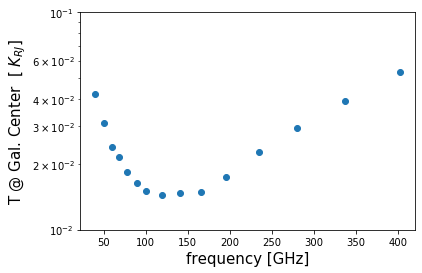

```python
pl.semilogy (freqs.value , cval*1e-6, 'o'   )
pl.xlabel('frequency [GHz]', fontsize=15)
pl.ylabel('T @ Gal. Center  '+r'[ $K_{RJ} $]', fontsize=15)
pl.ylim((1e-2,1e-1))
#pl.grid(True)
```

**Fig1** Brightness temperature of the Galactic center in all the Litebird frequency bands. Emission comes from synchrotron, free-free, AME and thermal dust.

## Taking into account CO lines and Top-hat bandpasses

PySM allows to perform bandpass integration (if it's given as an input the bandpass function ).

For the sake of simplicity, i've tested so far **top-hat** bandpasses.

```python
from so_pysm_models import COLines

dic_COlines = {'10': 115.271,'21': 230.538,'32': 345.796,'43':461.084 }
lines = np.array( list( dic_COlines.keys() ))
cval2 =np.zeros(nchannels)
for i in range(nchannels )  :
    bandwidth =bandwidths[i]/2.
    #print ( "processing {}".format(freqs[i] ))
    bandpass = np.linspace(freqs[i]  - (bandwidth*freqs [i]) , freqs [i] + (bandwidth*freqs [i]) , 16)
    m = sky.get_emission(bandpass )
    coinclude  = ( [  np. abs ( freqs[i].value   - fCO)  < (bandwidth*freqs [i]  ).value for fCO in dic_COlines.values() ] )
    if pl.sum(coinclude):
        co = COLines(target_nside=nside ,
                     output_units= m.unit, line=   lines[coinclude][0]   , coord='G')
        bandpass_weight=1./(2.* bandwidth*freqs [i]).value
        #plt.figure()
        #hp.gnomview(m[0], norm='hist', xsize=200 , reso=5 , sub=121)

        m += bandpass_weight  *  co.signal() *u.uK_RJ
        #hp.gnomview(m[0], norm='hist', xsize=200 , reso=5 , sub=122)

    msmoothed = pysm.apply_smoothing_and_coord_transform( m  , fwhm= fwhm[i])
    cval2[i]=(msmoothed[0] [lpix]. max() ).value
```

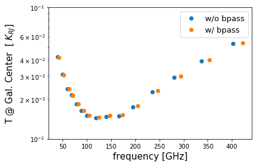

```python
pl.semilogy (freqs.value ,  cval*1e-6, 'o', label='w/o bpass'    )
pl.semilogy (freqs.value *(1.05),  cval2*1e-6, 'o'  , label='w/ bpass'  )
pl.xlabel('frequency [GHz]', fontsize=15)
pl.ylabel('T @ Gal. Center  '+r'[ $K_{RJ} $]', fontsize=15)
pl.ylim((1e-2,1e-1))
pl.legend(fontsize=13)
#pl.grid(True)
```

**Fig2** (blue circles) As in **Fig1**. (orange circles) Brightness temperature of the Galactic center estimated at the Litebird frequency bands(top-hat bandpasses). Emission comes from synchrotron, free-free, AME, thermal dust and CO lines. Freq. centroids are misplaced for graphical purposes.

Differences between the estimates with and without bandpasses integration are of order of few percentages (up to 3%).